# Analysis of Infant and Juvenile Mortality

## Introduction

### The Importance of Analyzing Infant and Juvenile Mortality

Infant and juvenile mortality rates are critical indicators of a population’s overall health and well-being. From a public health perspective, studying these rates helps us to:

- **Identify Vulnerable Populations:** Pinpoint specific subgroups at higher risk.
- **Understand Health Disparities:** Uncover inequalities in healthcare access and quality.
- **Evaluate Interventions:** Assess the effectiveness of public health programs and policies.
- **Guide Resource Allocation:** Direct resources towards the most effective interventions and the populations in greatest need.

This analysis aims to explore the factors associated with infant and juvenile mortality using survival analysis techniques.

### Context and Inspiration

This analysis is inspired by the work of **Joseph Larmarange** in his online resource **Analyse-R**, specifically the chapter on **“Analyse de survie”**. We will adapt and expand upon the methodologies presented there.

Our adaptation will focus on a **“tidy”** approach to the analysis, leveraging the power of the **tidyverse** ecosystem. This includes using packages like `broom` for tidying model outputs and `kableExtra` for creating professional, publication-ready tables.

### Data Set Presentation

The data for this analysis comes from the `questionr` package and is an English version of the data used in Larmarange’s example. It is a fictive dataset from a fertility survey.

The dataset consists of three data frames with labeled data, as if they were imported from SPSS with the `{haven}` package:

- **`households`**: Contains information about the households selected for the survey.
- **`women`**: Includes responses from the questionnaire administered to all women aged 15-49 living in the selected households.
- **`children`**: Contains one record for each child of the surveyed women.

These data frames can be linked using the `id_household` and `id_woman` variables.

### Workflow Presentation

Our analysis will follow these steps:

1. **Data Processing:** Loading, cleaning, and preparing the data for analysis. This includes variable transformations and creating new variables.
2. **Exploratory Data Analysis (EDA):** Visualizing and summarizing the data to understand its structure and identify potential relationships between variables.
3. **Feature Choosing:** Selecting the most relevant variables for our survival models.
4. **Kaplan-Meier (KM) Analysis:** Estimating and visualizing survival curves for different subgroups.
5. **Cox Proportional Hazards Model:** Building a multivariate model to identify the factors significantly associated with the risk of mortality.

## Data Preparation

### Loading Packages

First, we load the necessary R packages for our analysis.

```r
library(tidyverse)
library(questionr)
library(survival)
library(survminer)
library(kableExtra)
library(broom)
```

## Loading the Data

We load the `fertility` dataset from the `questionr` package. This will load the three data frames (`households`, `women`, and `children`) into our R environment.

```r
data(fertility)
```

```r
head(children) %>%
  kable() %>%
  kable_styling(bootstrap_options = c("striped", "hover", "condensed"))
```

| id_child | id_woman | date_of_birth | sex | alive | age_at_death |
| --- | --- | --- | --- | --- | --- |
| 1 | 1 | 2010-03-19 | 2 | 1 | NaN |
| 2 | 2 | 2009-10-14 | 2 | 0 | 0 |
| 3 | 2 | 2009-10-14 | 1 | 0 | 0 |
| 4 | 4 | 2008-02-24 | 1 | 1 | NaN |
| 5 | 5 | 2007-12-18 | 2 | 1 | NaN |
| 6 | 7 | 2008-05-07 | 1 | 1 | NaN |

## Data processing

Now, we will process the `children` data frame to prepare it for survival analysis.

### Calculating the Observation Period

Here we’ll be joining the `children` and `women` dataframes and calculate the observation period in months. We use the difference between the `interview_date` and `date_of_birth` to determine the children’s ages at the time of the study.

```r
children <- children %>%
  left_join(women %>% select(id_woman, interview_date),
            by = "id_woman") %>%
  mutate(
    observation_period = interval(date_of_birth, interview_date) %>%
      time_length(unit = "month")
  )
```

```r
# Check the summary of the observation period
summary(children$observation_period)
```

```
##    Min. 1st Qu.  Median    Mean 3rd Qu.    Max.
## -0.7742 13.7097 28.1001 28.8301 44.0726 59.8387
```

We can see some negative values, which means some children were born after the interview date. We also see that the maximum observation period is approximately 60 months (5 years), which is the maximum age we are interested in for this analysis.

#### Correcting for negative observation periods

If a child’s date of birth is after the recorded interview date, we assume the interviewer returned one month later for a follow-up. In such cases, we adjust the interview date by adding one month. After correcting the interview dates, we recalculate the observation period accordingly.

```r
children <- children %>%
  mutate(
    interview_date = if_else(date_of_birth > interview_date,
                             interview_date %m+% months(1),
                             interview_date),
    observation_period = interval(date_of_birth, interview_date) %>%
      time_length(unit = "month")
  )
```

```r
# Check the summary of the observation period again to ensure there are no more negative values
summary(children$observation_period)
```

```
##    Min. 1st Qu.  Median    Mean 3rd Qu.    Max.
##   0.129  13.710  28.100  28.837  44.073  59.839
```

### Imputing Age at Death

The `age_at_death` is recorded in completed months. For survival analysis, it’s better to have exact times. To address this, we’ll add a random fraction of a month to each `age_at_death` to simulate a more precise time of death within the month. We use a uniform distribution for this imputation, assuming deaths are evenly distributed throughout the month.

```r
children <- children %>%
  mutate(
    age_at_death_imputed = age_at_death + runif(n())
  )
```

### Creating Survival Variables

For survival analysis, we need two key variables:

- **`time`**: The follow-up time. This will be the `age_at_death_imputed` for children who have died and the `observation_period` for those who are still alive (censored).
- **`event`**: The status indicator. This will be `1` if the child has died and `0` if they are alive.

The `alive` variable is coded as `0` for deceased and `1` for alive, so we will reverse this for our `event` variable.

```r
children <- children %>%
 mutate(event = if_else(alive == 0, 1, 0),
        time = if_else(event == 1, age_at_death_imputed, observation_period))
```

## Exploratory Data Analysis (EDA)

*(This section is reserved for a future detailed exploratory data analysis. The goal of the EDA will be to understand the distributions of key variables, check for missing data, and visualize initial relationships between potential predictors and the survival outcome.)*

## Feature Selection

*(For this initial analysis, we will use the same set of variables as in the original Larmarange example to ensure comparability. In a subsequent iteration, a more formal feature selection process will be conducted. This could involve techniques like univariate Cox regression to screen variables, or more advanced methods like LASSO regression to select the most predictive features for the final model.)*

### Adding Explanatory Variables

Now we will add some explanatory variables from the `women` and `households` data frames to our `children` data frame.

Join with `women` and `households` dataframes to add more variables.

```r
children <- children %>%
  left_join(
    women %>% select(id_woman, id_household, mother_birth_date = date_of_birth, residency, instruction, ideal_nb_children),
    by = "id_woman"
    ) %>%
  left_join(
    households %>% select(id_household, structure, wealth ),
    by = "id_household"
  )
```

### Variable Recoding and Creation

We will now prepare our categorical and continuous variables for the analysis :

- Convert all labeled variables (except `ideal_nb_children`) to factors.
- Drop unused factor levels for `structure` and set the reference level.
- Combine `secondary` and `higher` education levels due to the small number of `higher` observations.
- Calculate the mother’s age at the birth of the child.
- Create age groups for the mother’s age at birth and set the reference level.

```r
children <- children %>%
  mutate(
    across(c(where(labelled::is.labelled), -ideal_nb_children), as_factor),
    structure = fct_drop(structure) %>% fct_relevel("one man and one woman"),
    instruction = fct_recode(instruction, "secondary & higher" = "secondary", "secondary & higher" = "higher"),
    mother_age_at_birth = time_length(interval(mother_birth_date, date_of_birth), unit = "years"),
    grp_mother_age_at_birth = cut(
      mother_age_at_birth,
      include.lowest = TRUE, right = FALSE,
      breaks = c(-Inf, 20, 30, Inf),
      labels = c("Under 20", "20–29", "30+")
    ) %>% fct_relevel("20–29")
  )
```

Finally, we will create a `birth_rank` variable.

**Note:** This variable is likely biased because we do not know the total number of children the mother has had. We are creating it here for demonstration purposes only.

```r
children <- children %>%
 group_by(id_woman) %>%
 mutate(
 birth_rank = rank(date_of_birth, ties.method = "max"),
 rank_after_ideal = factor(
   if_else(birth_rank > as.integer(ideal_nb_children), "yes", "no"),
   levels = c("no", "yes"))
 ) %>%
  ungroup()
```

## Kaplan-Meier Analysis

The KM estimator provides a non-parametric estimate of the survival function, which is the probability of an individual surviving past a certain time.

### Global Kaplan-Meier Estimate

First, we compute the overall survival estimate for the entire dataset. This gives us a baseline understanding of child survival in our sample over the 5-year period.

The `Surv(time, event) ~ 1` formula indicates we are modeling survival (`time` and `event` variables) without any grouping variables.

```r
# Fit the global Kaplan-Meier model
km_global <- survfit(Surv(time, event) ~ 1, data = children)

# Print the model summary
km_global
```

```
## Call: survfit(formula = Surv(time, event) ~ 1, data = children)
##
##         n events median 0.95LCL 0.95UCL
## [1,] 1584    142     NA      NA      NA
```

The output from `km_global` provides a summary of the survival data:

- **n**: The total number of children in the study (1584).
- **events**: The total number of deaths observed (142).
- **median**: The median survival time. In this case, it is `NA` (Not Available). This is common in survival analysis and indicates that the survival probability never drops to 50% during the observation period. In other words, more than half of the children survived the full follow-up time.
- **0.95 LCL, 0.95 UCL**: The lower and upper confidence limits for the median survival time.

To get a more detailed view, we can examine the survival probabilities at specific time points (e.g., at 1, 2, 3, and 4 years).

```r
# Display survival probabilities at specific time points (in months)
summary(km_global, times = c(0, 12, 24, 36, 48, 59))
```

```
## Call: survfit(formula = Surv(time, event) ~ 1, data = children)
##
##  time n.risk n.event survival std.err lower 95% CI upper 95% CI
##     0   1584       0    1.000 0.00000        1.000        1.000
##    12   1131     111    0.925 0.00686        0.912        0.939
##    24    827      18    0.910 0.00766        0.895        0.925
##    36    539      10    0.899 0.00835        0.882        0.915
##    48    254       2    0.895 0.00869        0.878        0.912
##    59     21       1    0.891 0.00941        0.873        0.910
```

### Visualizing the Global Survival Curve

A survival curve is a graphical representation of the survival function. The y-axis shows the estimated survival probability, and the x-axis shows time.

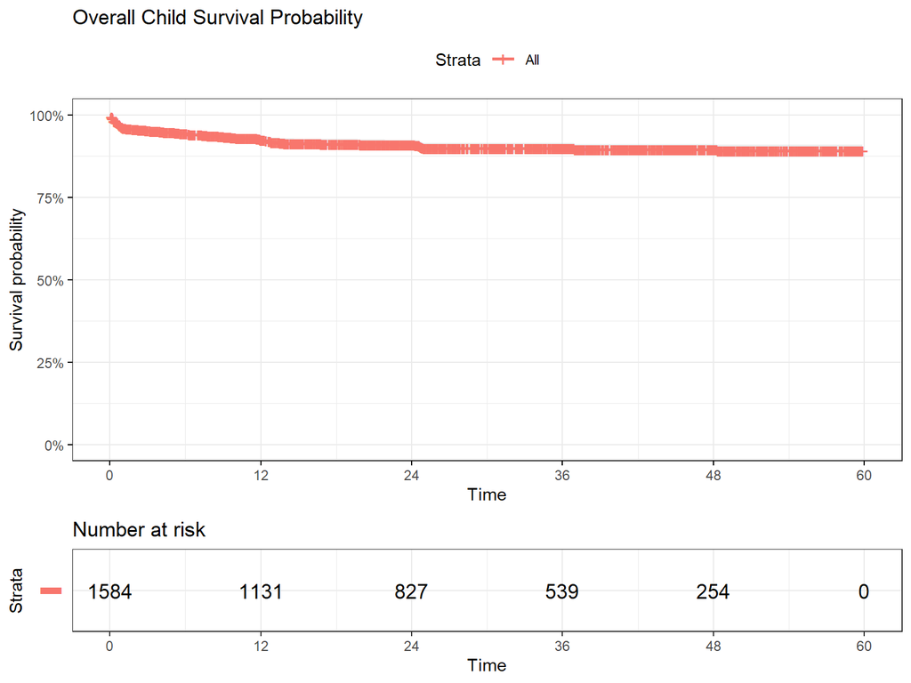

```r
ggsurvplot(
  km_global,
  risk.table = TRUE,
  conf.int = TRUE,
  surv.scale = "percent",
  break.time.by = 12,
  ggtheme = theme_bw(),
  risk.table.y.text = FALSE,
  title = "Overall Child Survival Probability"
)
```

### Visualizing the Cumulative Event Function

When the event rate is low (i.e., survival is high), the survival curve can look quite flat, making it hard to see trends. An alternative is to plot the cumulative event function, which is simply `1 - Survival Probability`. This shows the cumulative proportion of individuals who have experienced the event over time.

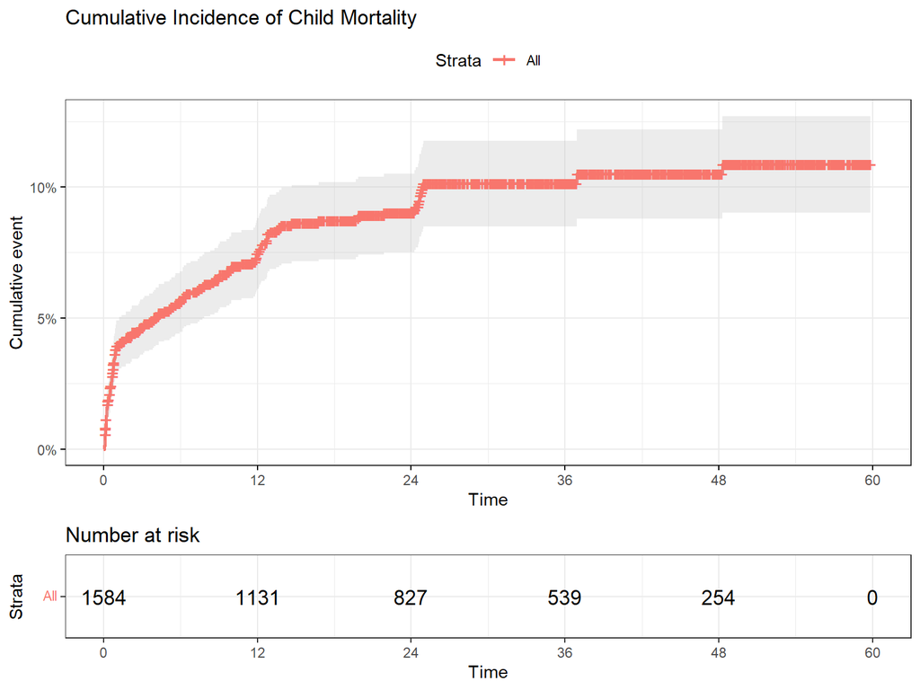

```r
# Cumulative event (1 - S(t))
ggsurvplot(
  km_global,
  fun = "event",
  risk.table = TRUE,
  conf.int = TRUE,
  surv.scale = "percent",
  break.time.by = 12,
  ggtheme = theme_bw(),
  title = "Cumulative Incidence of Child Mortality"
  )
```

The cumulative event plot makes the trend more apparent. We can see that the risk of mortality increases over time, reaching approximately 11% by the end of the 5-year follow-up period.

## Bivariate Analysis: Survival by Sex

Now, let’s compare the survival curves for different groups. We’ll start by comparing male and female children. To formally test for a statistically significant difference between the curves, we use the **log-rank test**.

The null hypothesis ($H_0$) of the log-rank test is that there is no difference in survival between the groups. A small p-value (< 0.05) provides evidence against the null hypothesis, suggesting that the survival experiences of the groups are different.

```r
# Fit Kaplan-Meier model stratified by sex
km_sex <- survfit(Surv(time, event) ~ sex, data = children)

# Perform log-rank test
survdiff(Surv(time, event) ~ sex, data = children)
```

```
## Call:
## survdiff(formula = Surv(time, event) ~ sex, data = children)
##
##              N Observed Expected (O-E)^2/E (O-E)^2/V
## sex=male   762       94     66.3      11.6      21.8
## sex=female 822       48     75.7      10.2      21.8
##
##  Chisq= 21.8  on 1 degrees of freedom, p= 3e-06
```

The output shows a **p-value of 3e-06**. Since this is much lower than the conventional significance level of 0.05, we do have sufficient evidence to reject the null hypothesis. We conclude that there is **statistically significant difference** in survival times between male and female children in this dataset.

Now, we visualize this comparison.

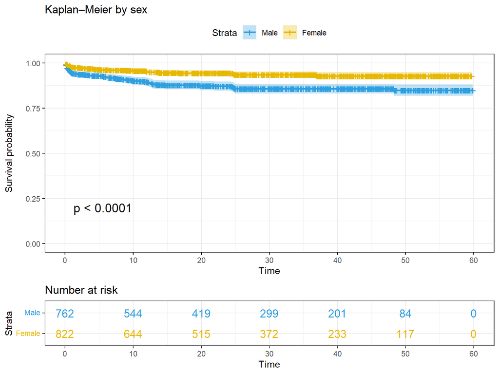

```r
# Plot Kaplan-Meier curves by sex
ggsurvplot(
  km_sex,
  conf.int = TRUE,
  pval = TRUE,
  risk.table = TRUE,
  risk.table.col = "strata",
  legend.labs = c("Male", "Female"),
  ggtheme = theme_bw(),
  palette = c("#2E9FDF", "#E7B800"),
  title = "Kaplan–Meier by sex"
)
```

The Kaplan-Meier plot visually confirms a significant difference in survival between sexes, with the curve for females positioned consistently above the curve for males. This separation, supported by a highly significant p-value (< 0.0001), indicates that female children have a statistically higher probability of survival throughout the follow-up period.

To view the cumulative event by group

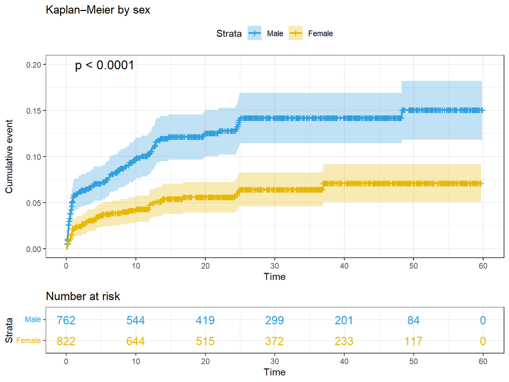

```r
ggsurvplot(
  km_sex,
  fun = "event",
  conf.int = TRUE,
  pval = TRUE,
  risk.table = TRUE,
  risk.table.col = "strata",
  legend.labs = c("Male", "Female"),
  ggtheme = theme_bw(),
  palette = c("#2E9FDF", "#E7B800"),
  title = "Kaplan–Meier by sex"
)
```

## Cox Proportional Hazards Model

While the Kaplan-Meier analysis is useful for visualizing survival and comparing groups, it is limited to one variable at a time. To assess the simultaneous effect of multiple predictors on survival, we use the **Cox Proportional Hazards model**.

This model estimates the **hazard ratio (HR)** for each predictor. The hazard is the instantaneous risk of the event (death) occurring at a certain time. An HR > 1 indicates an increased risk of the event for that group compared to the reference group, while an HR < 1 indicates a decreased risk.

### Full Model

First, we fit a model including all the selected predictors.

```r
mod1 <- coxph(
Surv(time, event) ~ sex + residency + wealth + structure + instruction + grp_mother_age_at_birth + rank_after_ideal,
 data = as.data.frame(children)
)
```

Display the model results in a tidy table.

```r
tidy(mod1, exponentiate = TRUE) %>%
  select(term, estimate, std.error, p.value) %>%
  rename(
    Variable = term,
    "Hazard Ratio (HR)" = estimate,
    "Std. Error" = std.error,
    "P-value" = p.value
  ) %>%
  kable(caption = "Cox Proportional Hazards Model - Full Model", digits = 3) %>%
  kable_styling(bootstrap_options = c("striped", "hover", "condensed", "responsive"))
```

Cox Proportional Hazards Model - Full Model

| Variable | Hazard Ratio (HR) | Std. Error | P-value |
| --- | --- | --- | --- |
| sexfemale | 0.445 | 0.178 | 0.000 |
| residencyrural | 1.918 | 0.270 | 0.016 |
| wealthpoor | 0.924 | 0.250 | 0.753 |
| wealthmedium | 1.384 | 0.248 | 0.190 |
| wealthrich | 1.414 | 0.298 | 0.246 |
| wealthvery rich | 1.593 | 0.429 | 0.277 |
| structureone adult | 0.867 | 0.600 | 0.812 |
| structuretwo adults of same sex | 1.844 | 0.376 | 0.104 |
| structurethree adults or more with family ties | 1.053 | 0.197 | 0.792 |
| structureadults with no family tie | 0.883 | 0.306 | 0.685 |
| instructionprimary | 0.968 | 0.206 | 0.874 |
| instructionsecondary & higher | 0.815 | 0.367 | 0.577 |
| grp_mother_age_at_birthUnder 20 | 0.734 | 0.268 | 0.248 |
| grp_mother_age_at_birth30+ | 0.995 | 0.192 | 0.981 |
| rank_after_idealyes | 3.960 | 0.603 | 0.022 |

The table displays the Hazard Ratio (HR) for each predictor, which quantifies the effect of that variable on the risk of death compared to a reference group.

We can visualize these hazard ratios using a forest plot.

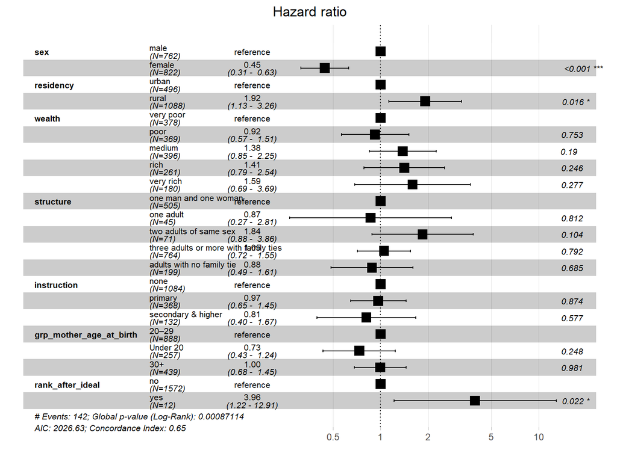

```r
# Create a forest plot to visualize the Hazard Ratios
ggforest(mod1)
```

The forest plot displays the hazard ratio (as a point) and its 95% confidence interval (as a horizontal line) for each predictor. If the confidence interval crosses the vertical line at 1, the result is not statistically significant at the 5% level. This plot provides a quick visual summary of the model results.

### Stepwise Model Selection

To build a more parsimonious model, we can use a stepwise selection procedure. This method automatically adds or removes predictors from the model to find a simpler model that still fits the data well, typically based on a criterion like AIC (Akaike Information Criterion).

```r
mod2 <- step(mod1, trace = 0)
```

Now let’s look at the results of this final, simplified model.

```r
tidy(mod2, exponentiate = TRUE) %>%
  select(term, estimate, std.error, p.value) %>%
  rename(
    Variable = term,
    "Hazard Ratio (HR)" = estimate,
    "Std. Error" = std.error,
    "P-value" = p.value
  ) %>%
  kable(caption = "Cox Proportional Hazards Model - Final Model after Stepwise Selection", digits = 3) %>%
  kable_styling(bootstrap_options = c("striped", "hover", "condensed", "responsive"))
```

Cox Proportional Hazards Model - Final Model after Stepwise Selection

| Variable | Hazard Ratio (HR) | Std. Error | P-value |
| --- | --- | --- | --- |
| sexfemale | 0.443 | 0.177 | 0.000 |
| residencyrural | 1.515 | 0.199 | 0.037 |
| rank_after_idealyes | 3.507 | 0.584 | 0.032 |

The stepwise selection process has refined the initial model, removing the least influential predictors to identify the most significant factors associated with child mortality. In this final model, three variables remain as key predictors: sex, residency, and whether the child’s birth rank exceeded the mother’s ideal number of children.

Finally, we visualize the results of this parsimonious model.

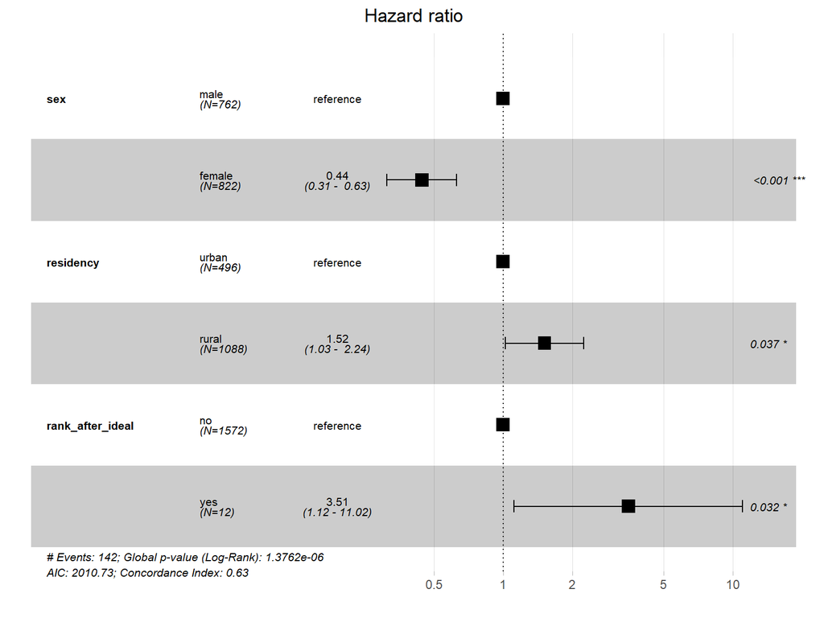

```r
ggforest(mod2)
```

### Model validity : Proportional Hazards Assumption

A core assumption of the Cox model is the **Proportional Hazards (PH) assumption**, which states that the effect of each predictor on the hazard of death is constant over time. We test this assumption using a test based on the **Schoenfeld residuals**.

#### Statistical Test

The `cox.zph()` function formally tests this assumption. The null hypothesis ($H_0$) is that the PH assumption holds true (i.e., the effect is constant over time).

```r
model_test <- cox.zph(mod2)
model_test
```

```
##                   chisq df    p
## sex              0.3583  1 0.55
## residency        0.0139  1 0.91
## rank_after_ideal 0.4203  1 0.52
## GLOBAL           0.8044  3 0.85
```

The table shows the results of the test for each variable individually and for the model globally. Since all the **p-values are much larger than 0.05**, we have no evidence to reject the null hypothesis. This suggests that the proportional hazards assumption is met for all variables and the model is valid in this regard.

#### Visual Inspection

We can visualize the Schoenfeld residuals to confirm the test results. If the assumption holds, we expect to see a random scatter of residuals around a horizontal line with a slope near zero.

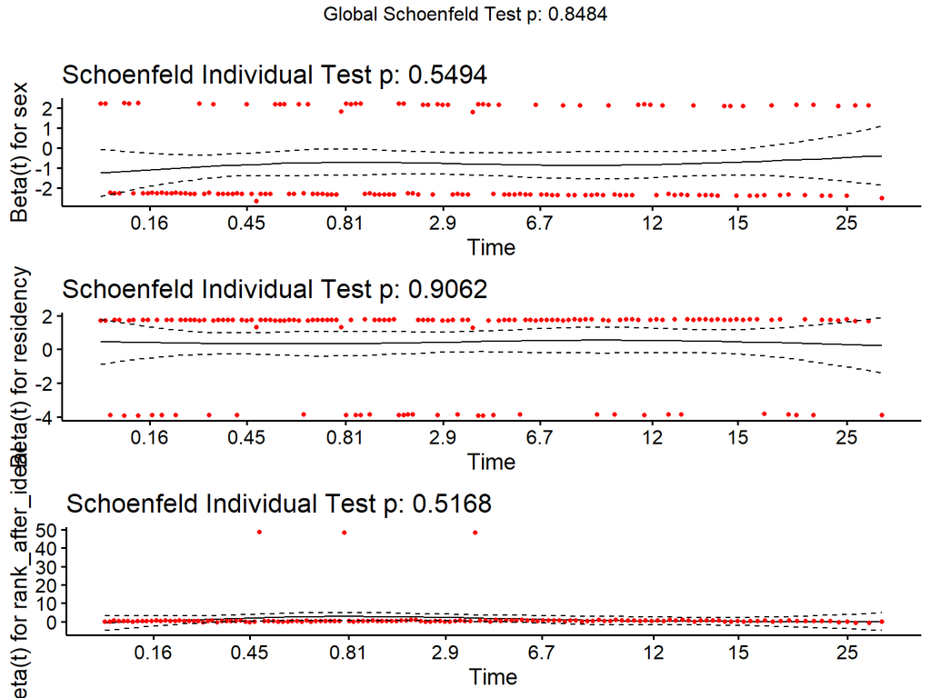

```r
ggcoxzph(model_test)
```